# Social Media MVA

```r
vss(scaled_time_data)
```

[output not shown]

[output cut: 20 more lines]

[output not shown]

[output not shown]

[output cut: 12 more lines]

[output not shown]

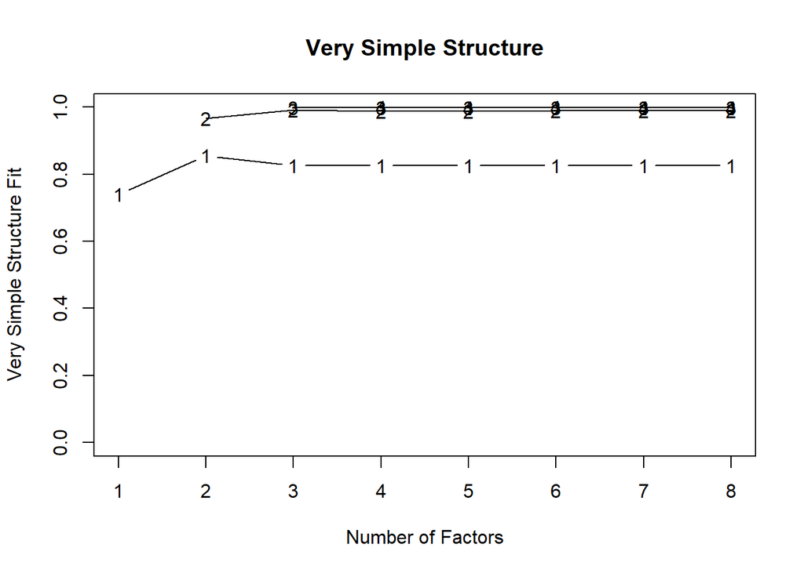

```
##
## Very Simple Structure
## Call: vss(x = scaled_time_data)
## VSS complexity 1 achieves a maximimum of 0.86  with  2  factors
## VSS complexity 2 achieves a maximimum of 0.99  with  3  factors
##
## The Velicer MAP achieves a minimum of 0.17  with  4  factors
## BIC achieves a minimum of  -5.84  with  3  factors
## Sample Size adjusted BIC achieves a minimum of  1.47  with  4  factors
##
## Statistics by number of factors
##   vss1 vss2  map dof   chisq    prob sqresid  fit   RMSEA      BIC   SABIC
## 1 0.74 0.00 0.55  20 2.1e+02 6.5e-33 7.07499 0.74    0.66  1.5e+02 2.1e+02
## 2 0.86 0.97 0.33  13 2.4e+09 0.0e+00 0.90955 0.97 2939.40  2.4e+09 2.4e+09
## 3 0.83 0.99 0.20   7 1.5e+01 3.0e-02 0.01471 1.00    0.24 -5.8e+00 1.6e+01
## 4 0.83 0.99 0.17   2 1.4e+00 5.0e-01 0.00223 1.00    0.00 -4.7e+00 1.5e+00
## 5 0.83 0.99 0.28  -2 8.4e-02      NA 0.00137 1.00      NA       NA      NA
## 6 0.83 0.99 0.46  -5 4.2e-02      NA 0.00062 1.00      NA       NA      NA
## 7 0.83 0.99 1.00  -7 9.9e-07      NA 0.00161 1.00      NA       NA      NA
## 8 0.83 0.99   NA  -8 9.3e-07      NA 0.00161 1.00      NA       NA      NA
##   complex  eChisq    SRMR  eCRMS  eBIC
## 1     1.0 1.0e+02 2.9e-01 0.3475  40.6
## 2     1.1 5.4e+00 6.8e-02 0.0997 -34.2
## 3     1.2 3.4e-02 5.4e-03 0.0107 -21.3
## 4     1.2 1.1e-03 9.5e-04 0.0035  -6.1
## 5     1.2 2.2e-05 1.4e-04     NA    NA
## 6     1.2 1.2e-05 1.0e-04     NA    NA
## 7     1.2 2.6e-10 4.7e-07     NA    NA
## 8     1.2 2.6e-10 4.7e-07     NA    NA
```

```r
# Computing Correlation Matrix
corrm.sm <- cor(scaled_time_data)
corrm.sm
```

```
##                Instagram_Time Linkedin_Time Snapchat_Time Twitter_Time
## Instagram_Time     1.00000000     0.2001230    0.09945917  0.483441518
## Linkedin_Time      0.20012297     1.0000000    0.92634630  0.290890950
## Snapchat_Time      0.09945917     0.9263463    1.00000000  0.124584829
## Twitter_Time       0.48344152     0.2908909    0.12458483  1.000000000
## Whatsapp_Time      0.44894402     0.8391584    0.81147325 -0.005624872
## Youtube_Time       0.24621965     0.9504195    0.90919829  0.451912244
## OTT_Time           0.44920752     0.4351652    0.31112287  0.967902109
## Reddit_Time        0.52999793     0.2839576    0.13409125  0.984791846
##                Whatsapp_Time Youtube_Time  OTT_Time Reddit_Time
## Instagram_Time   0.448944024    0.2462197 0.4492075  0.52999793
## Linkedin_Time    0.839158354    0.9504195 0.4351652  0.28395760
## Snapchat_Time    0.811473248    0.9091983 0.3111229  0.13409125
## Twitter_Time    -0.005624872    0.4519122 0.9679021  0.98479185
## Whatsapp_Time    1.000000000    0.7419399 0.1196354  0.01868572
## Youtube_Time     0.741939888    1.0000000 0.5890963  0.44754901
## OTT_Time         0.119635420    0.5890963 1.0000000  0.96376316
## Reddit_Time      0.018685717    0.4475490 0.9637632  1.00000000
```

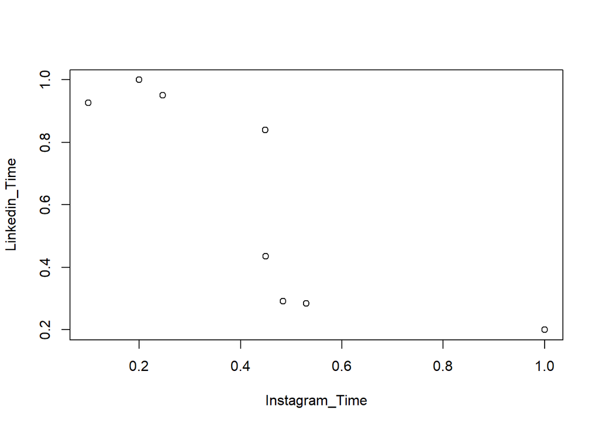

```r
plot(corrm.sm)
```

```r
sm_pca <- prcomp(scaled_time_data, scale=TRUE)
summary(sm_pca)
```

```
## Importance of components:
##                           PC1    PC2    PC3     PC4     PC5    PC6     PC7
## Standard deviation     2.1261 1.5649 0.9439 0.27533 0.17417 0.1232 0.10499
## Proportion of Variance 0.5651 0.3061 0.1114 0.00948 0.00379 0.0019 0.00138
## Cumulative Proportion  0.5651 0.8712 0.9825 0.99202 0.99581 0.9977 0.99908
##                            PC8
## Standard deviation     0.08563
## Proportion of Variance 0.00092
## Cumulative Proportion  1.00000
```

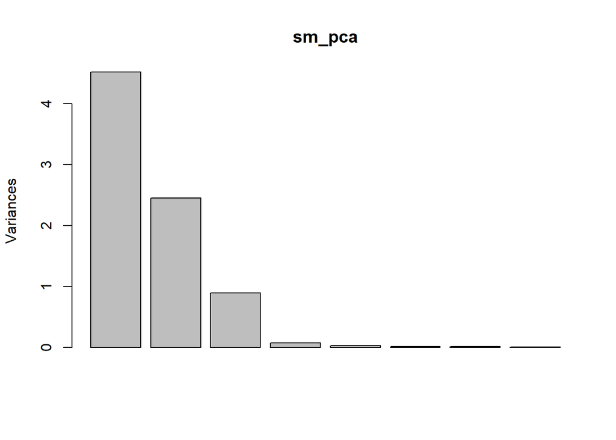

```r
plot(sm_pca)
```

```r
# A table containing eigenvalues and %'s accounted, follows. Eigenvalues are the sdev^2
(eigen_sm <- round(sm_pca$sdev^2,3))
```

```
## [1] 4.520 2.449 0.891 0.076 0.030 0.015 0.011 0.007
```

```r
round(fit.pc_sm$values, 3)
```

```
## [1] 4.520 2.449 0.891 0.076 0.030 0.015 0.011 0.007
```

```r
names(eigen_sm) <- paste("PC",1:8,sep="")
eigen_sm
```

```
##   PC1   PC2   PC3   PC4   PC5   PC6   PC7   PC8
## 4.520 2.449 0.891 0.076 0.030 0.015 0.011 0.007
```

```r
sumlambdas <- sum(eigen_sm)
sumlambdas
```

```
## [1] 7.999
```

```r
propvar <- round(eigen_sm/sumlambdas,2)
propvar
```

```
##  PC1  PC2  PC3  PC4  PC5  PC6  PC7  PC8
## 0.57 0.31 0.11 0.01 0.00 0.00 0.00 0.00
```

```r
cumvar_sm <- cumsum(propvar)
cumvar_sm
```

```
##  PC1  PC2  PC3  PC4  PC5  PC6  PC7  PC8
## 0.57 0.88 0.99 1.00 1.00 1.00 1.00 1.00
```

```r
matlambdas <- rbind(eigen_sm,propvar,cumvar_sm)
matlambdas
```

```
##            PC1   PC2   PC3   PC4  PC5   PC6   PC7   PC8
## eigen_sm  4.52 2.449 0.891 0.076 0.03 0.015 0.011 0.007
## propvar   0.57 0.310 0.110 0.010 0.00 0.000 0.000 0.000
## cumvar_sm 0.57 0.880 0.990 1.000 1.00 1.000 1.000 1.000
```

```r
rownames(matlambdas) <- c("Eigenvalues","Prop. variance","Cum. prop. variance")
rownames(matlambdas)
```

```
## [1] "Eigenvalues"         "Prop. variance"      "Cum. prop. variance"
```

```r
eigvec.sm <- sm_pca$rotation
print(sm_pca)
```

```
## Standard deviations (1, .., p=8):
## [1] 2.12614045 1.56490759 0.94388250 0.27533482 0.17416758 0.12320093 0.10498933
## [8] 0.08562715
##
## Rotation (n x k) = (8 x 8):
##                       PC1        PC2         PC3         PC4         PC5
## Instagram_Time -0.2477471  0.1880859  0.84132003  0.21094798  0.12839605
## Linkedin_Time  -0.4002537 -0.3085881 -0.13157415 -0.53314126 -0.25146045
## Snapchat_Time  -0.3543206 -0.3854248 -0.17423456  0.71516362 -0.22818425
## Twitter_Time   -0.3329341  0.4412965 -0.11995870 -0.21661133  0.08471808
## Whatsapp_Time  -0.3138458 -0.4072617  0.39092063 -0.29017730 -0.22144674
## Youtube_Time   -0.4319795 -0.2033958 -0.19645677  0.02634729  0.81044270
## OTT_Time       -0.3790209  0.3539820 -0.18625604  0.16691983 -0.39275079
## Reddit_Time    -0.3365529  0.4399626 -0.06336853 -0.01107272 -0.03045781
##                        PC6         PC7        PC8
## Instagram_Time  0.15043237 -0.26654226  0.2019070
## Linkedin_Time   0.06194170 -0.49340623  0.3640057
## Snapchat_Time  -0.09210725 -0.26414492 -0.2318699
## Twitter_Time    0.27138684 -0.26202502 -0.6954255
## Whatsapp_Time  -0.14380318  0.53931677 -0.3715324
## Youtube_Time    0.08277380  0.21273896  0.1542975
## OTT_Time        0.43706986  0.45844319  0.3362037
## Reddit_Time    -0.82026693  0.02802253  0.1203168
```

```r
# Taking the first two PCs to generate linear combinations for all the variables with two factors
pcafactors.sm <- eigvec.sm[,1:2]
pcafactors.sm
```

```
##                       PC1        PC2
## Instagram_Time -0.2477471  0.1880859
## Linkedin_Time  -0.4002537 -0.3085881
## Snapchat_Time  -0.3543206 -0.3854248
## Twitter_Time   -0.3329341  0.4412965
## Whatsapp_Time  -0.3138458 -0.4072617
## Youtube_Time   -0.4319795 -0.2033958
## OTT_Time       -0.3790209  0.3539820
## Reddit_Time    -0.3365529  0.4399626
```

```r
# Multiplying each column of the eigenvector’s matrix by the square-root of the corresponding eigenvalue in order to get the factor loadings
unrot.fact.sm <- sweep(pcafactors.sm,MARGIN=2,sm_pca$sdev[1:2],`*`)
unrot.fact.sm
```

```
##                       PC1        PC2
## Instagram_Time -0.5267451  0.2943370
## Linkedin_Time  -0.8509956 -0.4829119
## Snapchat_Time  -0.7533353 -0.6031542
## Twitter_Time   -0.7078646  0.6905882
## Whatsapp_Time  -0.6672802 -0.6373269
## Youtube_Time   -0.9184491 -0.3182956
## OTT_Time       -0.8058517  0.5539491
## Reddit_Time    -0.7155587  0.6885008
```

```r
# Computing communalities
communalities.sm <- rowSums(unrot.fact.sm^2)
communalities.sm
```

```
## Instagram_Time  Linkedin_Time  Snapchat_Time   Twitter_Time  Whatsapp_Time
##      0.3640947      0.9573974      0.9313091      0.9779844      0.8514485
##   Youtube_Time       OTT_Time    Reddit_Time
##      0.9448608      0.9562567      0.9860576
```

```r
# Performing the varimax rotation. The default in the varimax function is norm=TRUE thus, Kaiser normalization is carried out
rot.fact.sm <- varimax(unrot.fact.sm)
#View(unrot.fact.fish)
rot.fact.sm
```

```
## $loadings
##
## Loadings:
##                PC1    PC2
## Instagram_Time -0.184  0.575
## Linkedin_Time  -0.951  0.229
## Snapchat_Time  -0.962
## Twitter_Time           0.988
## Whatsapp_Time  -0.923
## Youtube_Time   -0.888  0.395
## OTT_Time       -0.210  0.955
## Reddit_Time            0.992
##
##                  PC1   PC2
## SS loadings    3.554 3.415
## Proportion Var 0.444 0.427
## Cumulative Var 0.444 0.871
##
## $rotmat
##           [,1]       [,2]
## [1,] 0.7304162 -0.6830023
## [2,] 0.6830023  0.7304162
```

```r
# The print method of varimax omits loadings less than abs(0.1). In order to display all the loadings, it is necessary to ask explicitly the contents of the object $loadings
fact.load.sm <- rot.fact.sm$loadings[1:8,1:2]
fact.load.sm
```

```
##                        PC1          PC2
## Instagram_Time -0.18371030  0.574756629
## Linkedin_Time  -0.95141091  0.228505290
## Snapchat_Time  -0.96220403  0.073976188
## Twitter_Time   -0.04536249  0.987889979
## Whatsapp_Time  -0.92268803 -0.009759986
## Youtube_Time   -0.88824669  0.394814608
## OTT_Time       -0.21025863  0.955012034
## Reddit_Time    -0.05240805  0.991620385
```

```r
as.matrix(scaled_time_data)%*%fact.load.sm%*%solve(t(fact.load.sm)%*%fact.load.sm)
```

```
##               PC1         PC2
##  [1,] -0.27002423  4.30926911
##  [2,]  0.42159452 -0.29805683
##  [3,]  0.15601537 -0.21154573
##  [4,]  0.20122279 -0.19069227
##  [5,]  0.43909788 -0.02588294
##  [6,]  0.19530986 -0.27734893
##  [7,]  0.48112089 -0.30522308
##  [8,]  0.29439047 -0.28461736
##  [9,] -4.19113025 -0.56935853
## [10,]  0.37222364 -0.27849000
## [11,] -0.04550933 -0.34762109
## [12,]  0.35322547 -0.18428279
## [13,] -0.73168943  0.22957388
## [14,]  0.36484196 -0.11956168
## [15,]  0.34960214 -0.04915554
## [16,]  0.31641384 -0.10801865
## [17,]  0.33197999 -0.08781648
## [18,]  0.06820549 -0.31738541
## [19,]  0.43533413 -0.30679090
## [20,]  0.27621214 -0.25809200
## [21,]  0.18156267 -0.31890276
```

```r
# Show the columns (variables) that go into each factor
for (i in 1:ncol(fact.load.sm)) {
  cat("Variables for Factor PC", i, ":\n")
  print(rownames(fact.load.sm)[order(abs(fact.load.sm[, i]), decreasing = TRUE)])
  cat("\n")
}
```

```
## Variables for Factor PC 1 :
## [1] "Snapchat_Time"  "Linkedin_Time"  "Whatsapp_Time"  "Youtube_Time"
## [5] "OTT_Time"       "Instagram_Time" "Reddit_Time"    "Twitter_Time"
##
## Variables for Factor PC 2 :
## [1] "Reddit_Time"    "Twitter_Time"   "OTT_Time"       "Instagram_Time"
## [5] "Youtube_Time"   "Linkedin_Time"  "Snapchat_Time"  "Whatsapp_Time"
```

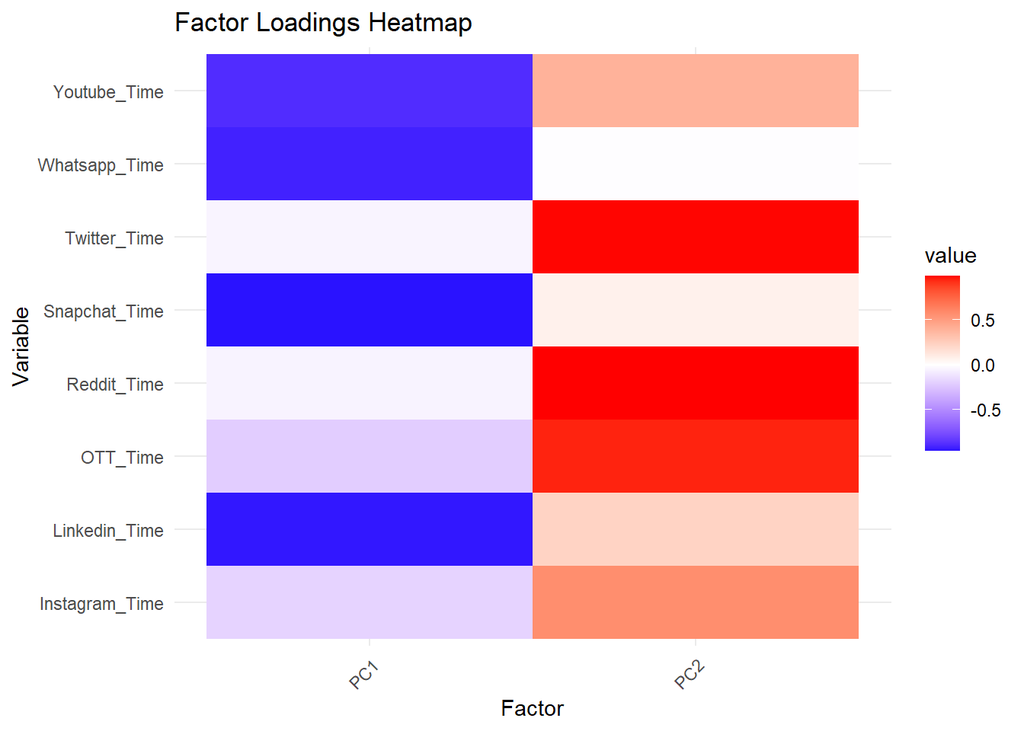

```r
# Convert factor loadings matrix to a data frame
fact_loadings_df <- as.data.frame(fact.load.sm)
# Add a column for variable names
fact_loadings_df$Variable <- rownames(fact_loadings_df)
# Reshape data for plotting
fact_loadings_df_long <- reshape2::melt(fact_loadings_df, id.vars = "Variable", variable.name = "Factor")

library(ggplot2)
#HeatMap
ggplot(fact_loadings_df_long, aes(x = Factor, y = Variable, fill = value)) +
     geom_tile() +
     scale_fill_gradient2(low = "blue", mid = "white", high = "red", midpoint = 0) +
     labs(x = "Factor", y = "Variable", title = "Factor Loadings Heatmap") +
     theme_minimal() +
     theme(axis.text.x = element_text(angle = 45, hjust = 1))
```

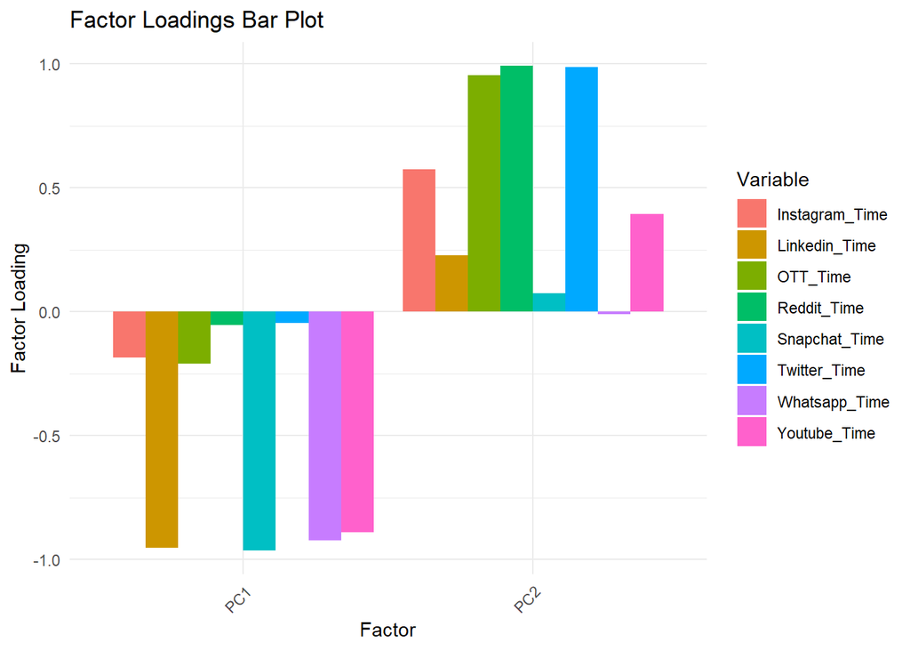

```r
#BarPlot
ggplot(fact_loadings_df_long, aes(x = Factor, y = value, fill = Variable)) +
     geom_bar(stat = "identity", position = "dodge") +
     labs(x = "Factor", y = "Factor Loading", fill = "Variable", title = "Factor Loadings Bar Plot") + theme_minimal() + theme(axis.text.x = element_text(angle = 45, hjust = 1),
           legend.position = "right")
```

Factor Analysis Insights:

The factor loadings depict the correlation between each social media platform and the underlying factors. Higher absolute loadings indicate a stronger association between the platform and the factor. Factors with loadings surpassing a certain threshold (e.g., 0.3 or 0.4) may be considered significant contributors to the respective factors. PCA Insights:

PCA identifies patterns and relationships among the social media platforms, condensing the information into principal components. Each principal component captures a portion of the total variance in the data, with higher proportions indicating greater importance in explaining the variability. The transformed data represents the original data projected onto the principal components, facilitating dimensionality reduction while retaining most of the variance. Comparison with the Class:

Comparing individual factor loadings or principal component scores with those of the class can unveil similarities or discrepancies in social media usage patterns. Similarities across factors/components may imply common trends or preferences within the class, while differences could signify unique behaviors or preferences. Interpretation of Clustering Results:

Clustering outcomes offer insights into how individuals or groups of individuals (clusters) exhibit similar behaviors across various social media platforms. Understanding cluster characteristics can inform targeted marketing strategies, personalized recommendations, or segmentation strategies based on social media usage patterns.